# ex 3b

Christoffer Mondrup Kramer

2023-05-20

# Exervcise 3b- Access normality for stiffness data in table 4.3 (p. 186)

Let us read the data

```r
df <- read.table("T4-3.dat", header = FALSE)
df
```

```
##      V1   V2   V3   V4    V5
## 1  1889 1651 1561 1778  0.60
## 2  2403 2048 2087 2197  5.48
## 3  2119 1700 1815 2222  7.62
## 4  1645 1627 1110 1533  5.21
## 5  1976 1916 1614 1883  1.40
## 6  1712 1712 1439 1546  2.22
## 7  1943 1685 1271 1671  4.99
## 8  2104 1820 1717 1874  1.49
## 9  2983 2794 2412 2581 12.26
## 10 1745 1600 1384 1508  0.77
## 11 1710 1591 1518 1667  1.93
## 12 2046 1907 1627 1898  0.46
## 13 1840 1841 1595 1741  2.70
## 14 1867 1685 1493 1678  0.13
```

[output cut: 16 more lines]

## Check normality for each of the four attributes

```r
library(MASS)

get_best_lambda <- function(data_vector) {
    # Transform data
    # Make box cox plot on our data
    df_box_cox<- boxcox(data_vector~1,lambda=seq(-2, 2, 1/10)) # Can also be seq(-.5, 1.5,.01)
    df_box_cox

    # Get best lambda
    max_lambda <- df_box_cox$x[which.max(df_box_cox$y)]
    print(paste("The best lambda is ", max_lambda))
    return(max_lambda)
}

box_cox_transformation <- function(data_vector){

  lambda <- get_best_lambda(data_vector)
  if (lambda == 0){
    transformed_vector <- log(data_vector)
  }

  else {
  transformed_vector <- ( (data_vector^lambda) - 1)/lambda
  }

  return(transformed_vector)
}


test_norm <- function(data_vector, signigicance = 0.05, transform_data = FALSE) {
  # You can chose the following significance levels
  # 0.01
  # 0.05
  # 0.10

  if (signigicance == 0.01){
    signigicance_col <- 2
  }

  else if (signigicance == 0.05){
    signigicance_col <- 3
  }

  else if (signigicance == 0.1){
    signigicance_col <- 4
  }


  # ----- QQ plot -----
  qq <- qqnorm(data_vector, main = "Original Data QQ plot")
  qqline(data_vector)

  print(paste("Length of data is ", length(data_vector)))
  # ----- Hypothesis test ------
  # Create Testing table
  n <- c(5, 10, 15, 20, 25, 30, 35, 40, 45, 50, 55, 60, 75, 100, 150, 200, 300)
  one <- c(0.8299, 0.8801, 0.9126, 0.9269, 0.9410,
        0.9479, 0.9538, 0.9599, 0.9632, 0.9671,
        0.9695, 0.9720, 0.9771, 0.9822, 0.9879, 0.9905, 0.9935)

  five <- c(0.8788, 0.9198, 0.9389,
        0.9508, 0.9591, 0.9652,
        0.9682, 0.9726, 0.9749,
        0.9768, 0.9787, 0.9801,
        0.9838, 0.9873, 0.9913, 0.9931, 0.9953)

  ten <- c(0.9032, 0.9351, 0.9503,
        0.9604, 0.9665, 0.9715,
        0.9740, 0.9771, 0.9792,
        0.9809, 0.9822, 0.9836,
        0.9866, 0.9895, 0.9928, 0.9942, 0.9960)
  testing_tbl <- data.frame(
  n,
  one,
  five,
  ten
  )

  # Find index of testing (n)
  sample_size <- length(data_vector)
  i <- 1
  prev_value = NaN
  for (n in testing_tbl$n){

    if (sample_size > testing_tbl$n[length(testing_tbl$n)]){
      i <- length(testing_tbl$n)
      break
    }

    if (n == sample_size){
      exact_sample_size <- TRUE
      break
    }

    else if ( n > sample_size & prev_value < sample_size){
      break
    }
    i <- i + 1
    prev_value <- n
  }

  print(testing_tbl[(i - 1) : i, ])
  # ----- Normal -------
  cor_coef <- cor(qq$x, qq$y)
  normality = FALSE
  if (cor_coef > testing_tbl[i, signigicance_col]){
    print(paste("With a correlation coefficient of ", cor_coef, "The data is normal within significance levels of", signigicance))
    normality = TRUE
    return(normality)
  }


  # ----- Not normal -----
  else {

    if (transform_data) {
      print(paste("With a correlation coefficient of ", cor_coef,
            "The data is not normal within significance levels of", signigicance, "Transforming data ... "))

      # Transform data
      z_vector <- box_cox_transformation(data_vector)

      # QQ plot on transformed data
      qqz <- qqnorm(z_vector, main = "Transformed Data QQ plot")
      qqline(z_vector)

      # Hypothesis test on transformed data
      z_cor_coef <- cor(qqz$x, qqz$y)
      if (z_cor_coef > testing_tbl[i, signigicance_col]){
        print(paste("With a correlation coefficient of ", z_cor_coef,
                    "The data is normal within significance levels of", signigicance,
                    "For the box cox transformed data"))
        normality = TRUE
        return(normality)
      }
      else {
          print(paste("With a correlation coefficient of ", z_cor_coef,
                "The data is normal within significance levels of", signigicance,
                "For the box cox transformed data"))
      }
    }
    else {
      print(paste("With a correlation coefficient of ", cor_coef,
      "The data is not normal within significance levels of", signigicance))
    }
  }
}
```

Let us check each attribute

```r
for (i in colnames(df)){
  print(i)
  test_norm(df[[i]], signigicance = 0.01)
}
```

```
## [1] "V1"
```

```
## [1] "Length of data is  30"
##    n    one   five    ten
## 5 25 0.9410 0.9591 0.9665
## 6 30 0.9479 0.9652 0.9715
## [1] "With a correlation coefficient of  0.959864226926573 The data is normal within significance levels of 0.01"
## [1] "V2"
```

```
## [1] "Length of data is  30"
##    n    one   five    ten
## 5 25 0.9410 0.9591 0.9665
## 6 30 0.9479 0.9652 0.9715
## [1] "With a correlation coefficient of  0.950390941215503 The data is normal within significance levels of 0.01"
## [1] "V3"
```

```
## [1] "Length of data is  30"
##    n    one   five    ten
## 5 25 0.9410 0.9591 0.9665
## 6 30 0.9479 0.9652 0.9715
## [1] "With a correlation coefficient of  0.963410375639771 The data is normal within significance levels of 0.01"
## [1] "V4"
```

```
## [1] "Length of data is  30"
##    n    one   five    ten
## 5 25 0.9410 0.9591 0.9665
## 6 30 0.9479 0.9652 0.9715
## [1] "With a correlation coefficient of  0.980292022100608 The data is normal within significance levels of 0.01"
## [1] "V5"
```

```
## [1] "Length of data is  30"
##    n    one   five    ten
## 5 25 0.9410 0.9591 0.9665
## 6 30 0.9479 0.9652 0.9715
## [1] "With a correlation coefficient of  0.891223192804262 The data is not normal within significance levels of 0.01"
```

```r
for (i in colnames(df)){
  print(i)
  test_norm(df[[i]], signigicance = 0.05)
}
```

```
## [1] "V1"
```

```
## [1] "Length of data is  30"
##    n    one   five    ten
## 5 25 0.9410 0.9591 0.9665
## 6 30 0.9479 0.9652 0.9715
## [1] "With a correlation coefficient of  0.959864226926573 The data is not normal within significance levels of 0.05"
## [1] "V2"
```

```
## [1] "Length of data is  30"
##    n    one   five    ten
## 5 25 0.9410 0.9591 0.9665
## 6 30 0.9479 0.9652 0.9715
## [1] "With a correlation coefficient of  0.950390941215503 The data is not normal within significance levels of 0.05"
## [1] "V3"
```

```
## [1] "Length of data is  30"
##    n    one   five    ten
## 5 25 0.9410 0.9591 0.9665
## 6 30 0.9479 0.9652 0.9715
## [1] "With a correlation coefficient of  0.963410375639771 The data is not normal within significance levels of 0.05"
## [1] "V4"
```

```
## [1] "Length of data is  30"
##    n    one   five    ten
## 5 25 0.9410 0.9591 0.9665
## 6 30 0.9479 0.9652 0.9715
## [1] "With a correlation coefficient of  0.980292022100608 The data is normal within significance levels of 0.05"
## [1] "V5"
```

```
## [1] "Length of data is  30"
##    n    one   five    ten
## 5 25 0.9410 0.9591 0.9665
## 6 30 0.9479 0.9652 0.9715
## [1] "With a correlation coefficient of  0.891223192804262 The data is not normal within significance levels of 0.05"
```

```r
for (i in colnames(df)){
  print(i)
  test_norm(df[[i]], signigicance = 0.10)
}
```

```
## [1] "V1"
```

```
## [1] "Length of data is  30"
##    n    one   five    ten
## 5 25 0.9410 0.9591 0.9665
## 6 30 0.9479 0.9652 0.9715
## [1] "With a correlation coefficient of  0.959864226926573 The data is not normal within significance levels of 0.1"
## [1] "V2"
```

```
## [1] "Length of data is  30"
##    n    one   five    ten
## 5 25 0.9410 0.9591 0.9665
## 6 30 0.9479 0.9652 0.9715
## [1] "With a correlation coefficient of  0.950390941215503 The data is not normal within significance levels of 0.1"
## [1] "V3"
```

```
## [1] "Length of data is  30"
##    n    one   five    ten
## 5 25 0.9410 0.9591 0.9665
## 6 30 0.9479 0.9652 0.9715
## [1] "With a correlation coefficient of  0.963410375639771 The data is not normal within significance levels of 0.1"
## [1] "V4"
```

```
## [1] "Length of data is  30"
##    n    one   five    ten
## 5 25 0.9410 0.9591 0.9665
## 6 30 0.9479 0.9652 0.9715
## [1] "With a correlation coefficient of  0.980292022100608 The data is normal within significance levels of 0.1"
## [1] "V5"
```

```
## [1] "Length of data is  30"
##    n    one   five    ten
## 5 25 0.9410 0.9591 0.9665
## 6 30 0.9479 0.9652 0.9715
## [1] "With a correlation coefficient of  0.891223192804262 The data is not normal within significance levels of 0.1"
```

**significance 0.01:**  
- x1: Normal  
- x2: Normal  
- x3: normal  
- x4: normal  
- x5: NOT normal

**significance: 0.05:**  
- x1: NOT Normal  
- x2: NOT Normal  
- x3: NOT normal  
- x4: normal  
- x5: NOT normal

**significance: 0.10:**  
- x1: NOT Normal  
- x2: NOT Normal  
- x3: NOT normal  
- x4: normal  
- x5: NOT normal

No matter what significance level there is always at least one attribute which is not normally distributed.  
Maybe we should transform it all? Let’s try:

```r
for (i in colnames(df)){
  print(i)
  test_norm(df[,i], signigicance = 0.01, transform_data = TRUE)
}
```

```
## [1] "V1"
```

```
## [1] "Length of data is  30"
##    n    one   five    ten
## 5 25 0.9410 0.9591 0.9665
## 6 30 0.9479 0.9652 0.9715
## [1] "With a correlation coefficient of  0.959864226926573 The data is normal within significance levels of 0.01"
## [1] "V2"
```

```
## [1] "Length of data is  30"
##    n    one   five    ten
## 5 25 0.9410 0.9591 0.9665
## 6 30 0.9479 0.9652 0.9715
## [1] "With a correlation coefficient of  0.950390941215503 The data is normal within significance levels of 0.01"
## [1] "V3"
```

```
## [1] "Length of data is  30"
##    n    one   five    ten
## 5 25 0.9410 0.9591 0.9665
## 6 30 0.9479 0.9652 0.9715
## [1] "With a correlation coefficient of  0.963410375639771 The data is normal within significance levels of 0.01"
## [1] "V4"
```

```
## [1] "Length of data is  30"
##    n    one   five    ten
## 5 25 0.9410 0.9591 0.9665
## 6 30 0.9479 0.9652 0.9715
## [1] "With a correlation coefficient of  0.980292022100608 The data is normal within significance levels of 0.01"
## [1] "V5"
```

```
## [1] "Length of data is  30"
##    n    one   five    ten
## 5 25 0.9410 0.9591 0.9665
## 6 30 0.9479 0.9652 0.9715
## [1] "With a correlation coefficient of  0.891223192804262 The data is not normal within significance levels of 0.01 Transforming data ... "
```

```
## [1] "The best lambda is  0.181818181818182"
```

```
## [1] "With a correlation coefficient of  0.996412803498558 The data is normal within significance levels of 0.01 For the box cox transformed data"
```

```r
for (i in colnames(df)){
  print(i)
  test_norm(df[[i]], signigicance = 0.05, transform_data = TRUE)
}
```

```
## [1] "V1"
```

```
## [1] "Length of data is  30"
##    n    one   five    ten
## 5 25 0.9410 0.9591 0.9665
## 6 30 0.9479 0.9652 0.9715
## [1] "With a correlation coefficient of  0.959864226926573 The data is not normal within significance levels of 0.05 Transforming data ... "
```

```
## [1] "The best lambda is  -0.626262626262626"
```

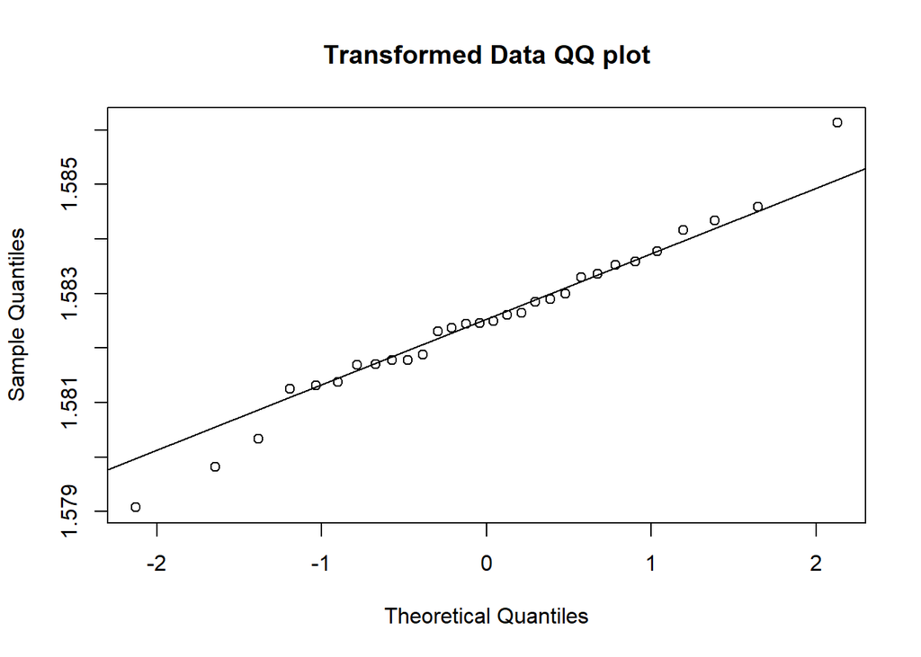

```
## [1] "With a correlation coefficient of  0.987535483360367 The data is normal within significance levels of 0.05 For the box cox transformed data"
## [1] "V2"
```

```
## [1] "Length of data is  30"
##    n    one   five    ten
## 5 25 0.9410 0.9591 0.9665
## 6 30 0.9479 0.9652 0.9715
## [1] "With a correlation coefficient of  0.950390941215503 The data is not normal within significance levels of 0.05 Transforming data ... "
```

```
## [1] "The best lambda is  -0.787878787878788"
```

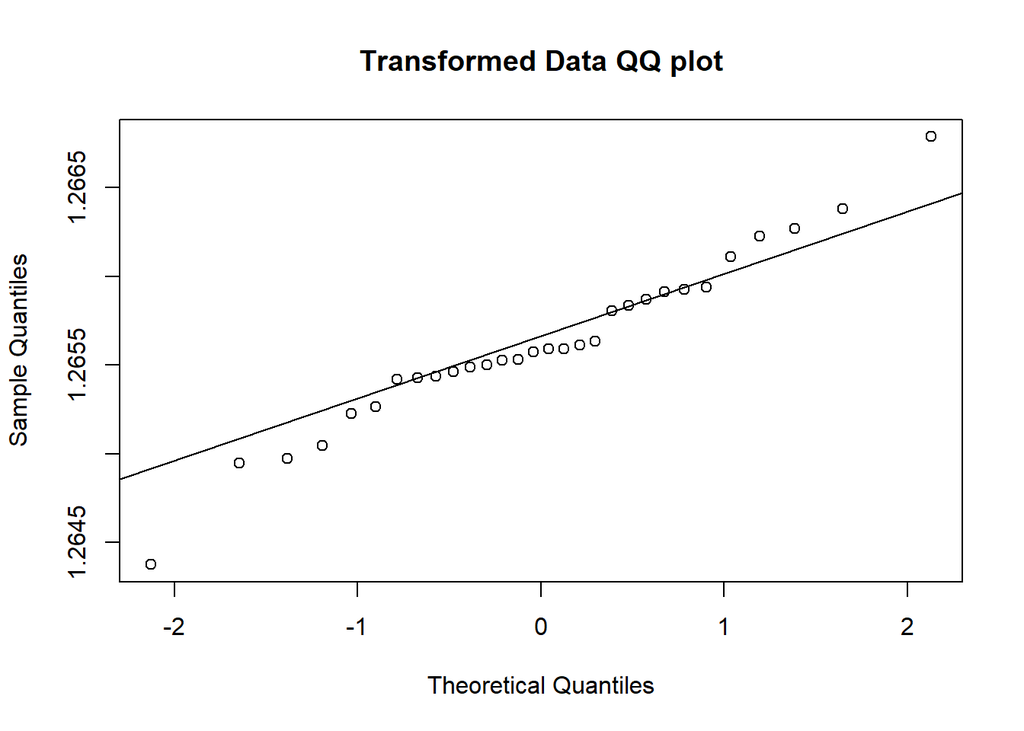

```
## [1] "With a correlation coefficient of  0.982798262680497 The data is normal within significance levels of 0.05 For the box cox transformed data"
## [1] "V3"
```

```
## [1] "Length of data is  30"
##    n    one   five    ten
## 5 25 0.9410 0.9591 0.9665
## 6 30 0.9479 0.9652 0.9715
## [1] "With a correlation coefficient of  0.963410375639771 The data is not normal within significance levels of 0.05 Transforming data ... "
```

```
## [1] "The best lambda is  -0.747474747474747"
```

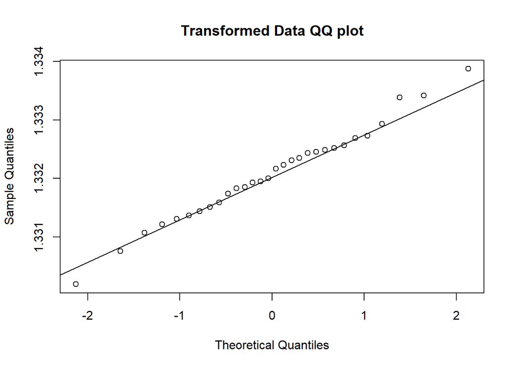

```
## [1] "With a correlation coefficient of  0.994189192711897 The data is normal within significance levels of 0.05 For the box cox transformed data"
## [1] "V4"
```

```
## [1] "Length of data is  30"
##    n    one   five    ten
## 5 25 0.9410 0.9591 0.9665
## 6 30 0.9479 0.9652 0.9715
## [1] "With a correlation coefficient of  0.980292022100608 The data is normal within significance levels of 0.05"
## [1] "V5"
```

```
## [1] "Length of data is  30"
##    n    one   five    ten
## 5 25 0.9410 0.9591 0.9665
## 6 30 0.9479 0.9652 0.9715
## [1] "With a correlation coefficient of  0.891223192804262 The data is not normal within significance levels of 0.05 Transforming data ... "
```

```
## [1] "The best lambda is  0.181818181818182"
```

```
## [1] "With a correlation coefficient of  0.996412803498558 The data is normal within significance levels of 0.05 For the box cox transformed data"
```

```r
for (i in colnames(df)){
  print(i)
  test_norm(df[[i]], signigicance = 0.10, transform_data = TRUE)
}
```

```
## [1] "V1"
```

```
## [1] "Length of data is  30"
##    n    one   five    ten
## 5 25 0.9410 0.9591 0.9665
## 6 30 0.9479 0.9652 0.9715
## [1] "With a correlation coefficient of  0.959864226926573 The data is not normal within significance levels of 0.1 Transforming data ... "
```

```
## [1] "The best lambda is  -0.626262626262626"
```

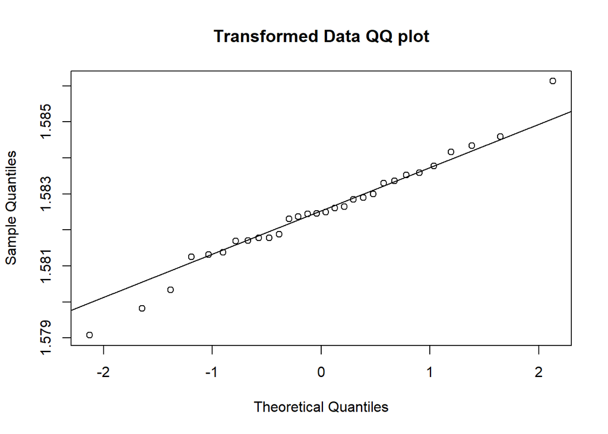

```
## [1] "With a correlation coefficient of  0.987535483360367 The data is normal within significance levels of 0.1 For the box cox transformed data"
## [1] "V2"
```

```
## [1] "Length of data is  30"
##    n    one   five    ten
## 5 25 0.9410 0.9591 0.9665
## 6 30 0.9479 0.9652 0.9715
## [1] "With a correlation coefficient of  0.950390941215503 The data is not normal within significance levels of 0.1 Transforming data ... "
```

```
## [1] "The best lambda is  -0.787878787878788"
```

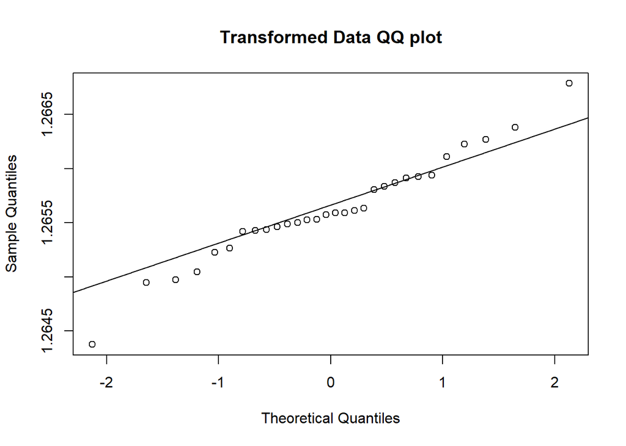

```
## [1] "With a correlation coefficient of  0.982798262680497 The data is normal within significance levels of 0.1 For the box cox transformed data"
## [1] "V3"
```

```
## [1] "Length of data is  30"
##    n    one   five    ten
## 5 25 0.9410 0.9591 0.9665
## 6 30 0.9479 0.9652 0.9715
## [1] "With a correlation coefficient of  0.963410375639771 The data is not normal within significance levels of 0.1 Transforming data ... "
```

```
## [1] "The best lambda is  -0.747474747474747"
```

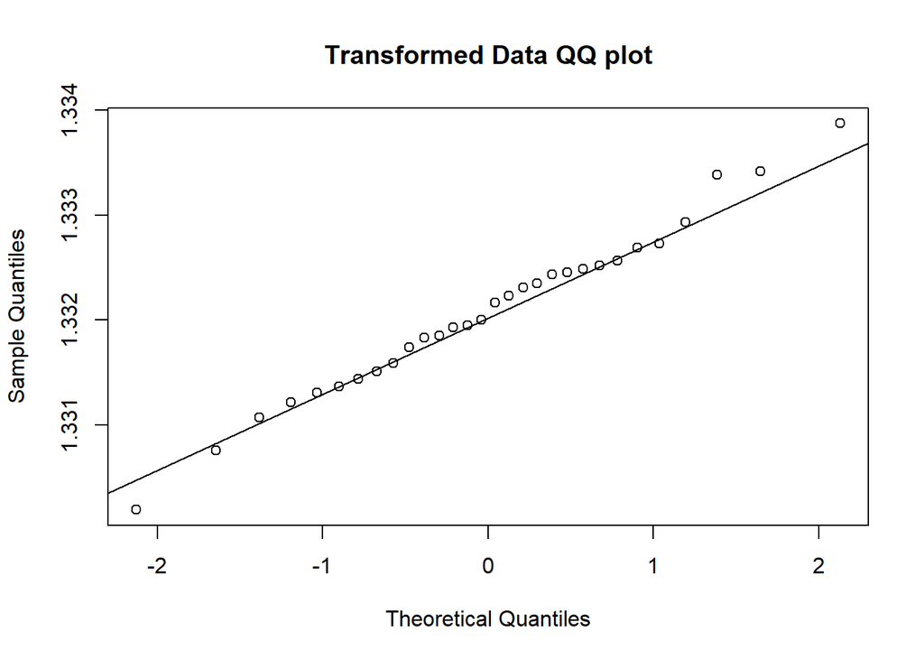

```
## [1] "With a correlation coefficient of  0.994189192711897 The data is normal within significance levels of 0.1 For the box cox transformed data"
## [1] "V4"
```

```
## [1] "Length of data is  30"
##    n    one   five    ten
## 5 25 0.9410 0.9591 0.9665
## 6 30 0.9479 0.9652 0.9715
## [1] "With a correlation coefficient of  0.980292022100608 The data is normal within significance levels of 0.1"
## [1] "V5"
```

```
## [1] "Length of data is  30"
##    n    one   five    ten
## 5 25 0.9410 0.9591 0.9665
## 6 30 0.9479 0.9652 0.9715
## [1] "With a correlation coefficient of  0.891223192804262 The data is not normal within significance levels of 0.1 Transforming data ... "
```

```
## [1] "The best lambda is  0.181818181818182"
```

```
## [1] "With a correlation coefficient of  0.996412803498558 The data is normal within significance levels of 0.1 For the box cox transformed data"
```

Overview of transformed data:  
**significance 0.01:**  
- x1: Normal  
- x2: Normal  
- x3: normal  
- x4: normal  
- x5: normal (when transformed)

**significance: 0.05:**  
- x1: Normal (when transformed)  
- x2: Normal (when transformed)  
- x3: Normal (when transformed)  
- x4: Normal  
- x5: Normal (when transformed)

**significance: 0.10:**  
- x1: Normal (when transformed)  
- x2: Normal (when transformed)  
- x3: Normal (when transformed)  
- x4: Normal  
- x5: Normal (when transformed)

## Check normality for each pair of the two attributes

```r
FindcrikChi <- function(n=30, p=2, alpha= 0.05, n_simulations=10000){

    cricvec <- rep(0, n_simulations)  #vector for the rQ result collection#

    for(i in 1:n_simulations){
        #iteration to estimate rQ#
        numvec <- rchisq(n, p)  #generate a data set of size n, degree of freedom=p#
        d <- sort(numvec)
        q <- qchisq((1:n-0.5)/n, p)
        cricvec[i] <- cor(d,q)
    }

    scricvec <- sort(cricvec)
    cN <- ceiling(n_simulations* alpha) #to be on the safe side I use ceiling instead of floor(), take the 'worst' alpha*N cor as rQ, everything lower than that is deemed as rejection#
    cricvalue <- scricvec[cN]
    result <- list(cN, cricvalue, scricvec)
    return(result[[2]])
}
```

This function takes two variables, the simulated correlation coefficient from preivouslky and a aplha/significance value and creates a qqplot. It then calculates mahalanobis distance for the data points and the correlation coefficient between the mahalanobis distances and a theoretical chi squared distribution. It then compares this correlation coefficient with the simulated coefficient and checks if it is higher. If it is higher, this data follows a chi-squared distribution, which indicates, that it is normally distributed. It also calculate how large a percent of the points that are within in alpha, that is how many percent of the points are within the 1 - alpha contours, and shows what would be expected. If it is not crazy far from the expected, the correlation coeefficient is a usefull measure.

```r
multi_var_norm <- function(df, sim_cor, alpha, name, remove_outlier = FALSE, n_outliers = 1) {

  # Data and parameters
  n <- nrow(df) # observations
  p <- ncol(df) # number of variables
  D2 <- mahalanobis(df,
                    center  = colMeans(df),
                    cov = cov(df)) # generalized squared distance

  # Removes outliers if necessary
  if(remove_outlier == TRUE){

    i = 0
    while (i < n_outliers){
    #This is where we remove outliers. This will most likely change the correlation value and the % number of points in the contour.
    D2 <- D2[-which.max(D2)]
    i = i + 1
    }
  }


  # Chi square qq plot
  chi_plot <- qqplot(qchisq(ppoints(n, a = .5), df = p), D2,
                     plot.it = F) # chi square plot values.

  my_cor <- cor(chi_plot$x, chi_plot$y) # correlation value
  critical_value <- qchisq(p = alpha,
                           df = p,
                           lower.tail = F) # calculate critical value

  # Proportion of points below alpha value
  prop_within_contour <- round(length(D2[D2 <= critical_value]) / length(D2),4) #


  quantiles <- quantile(D2)
  quantile_25 <- quantiles[2]
  quantile_50 <- quantiles[3]
  quantile_75 <- quantiles[4]

  plot(chi_plot, #From here and downwards it is only how you want the plot to look.
       ylab = 'Mahalanobis distances',
       xlab = 'Chi-square quantiles',
       main = paste0(name, ' alpha = ',alpha)) # plot chi square plot

  # Q line
  y <- rchisq(500, df = p)
  qqline(y, distribution = function(n) qchisq(n, df = p), prob = c(0.1, 0.6))

  # Lines for quantiles
  abline(h = quantile_50, lty = 2) # 50% quantiles becayse book p. 187
  abline(h = critical_value, lty = 2, col = "red") # Below Critical value

  if(my_cor > sim_cor){
    conclusion <- "Normally distributed!"
  }

  else {
    conclusion <- "NOT normally distributed!"
  }
  legend("topleft",
         paste0("r = ", round(my_cor,4), "\n",
                "Simulated r Value: ", sim_cor, "\n",
                "% Below critical range: ", prop_within_contour, "\n",
                "Expected if normal: ", 1-alpha, "\n",
                conclusion),
         cex = 0.75,
         bty = "n") # add legend to plot
  }
```

We then create a function which test each pair of variables for normality

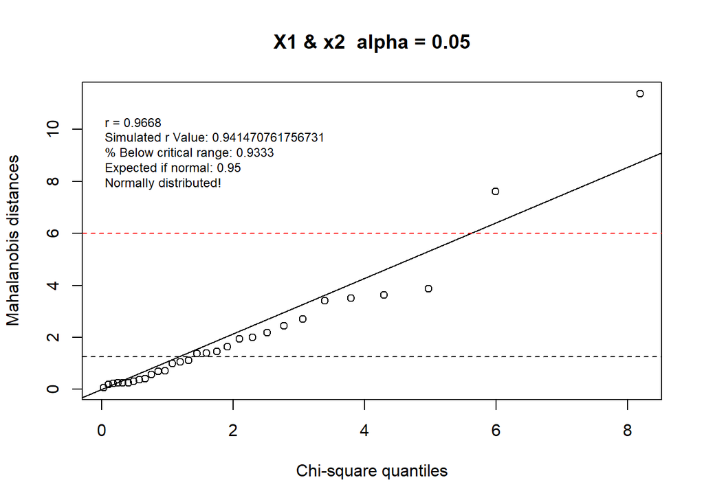

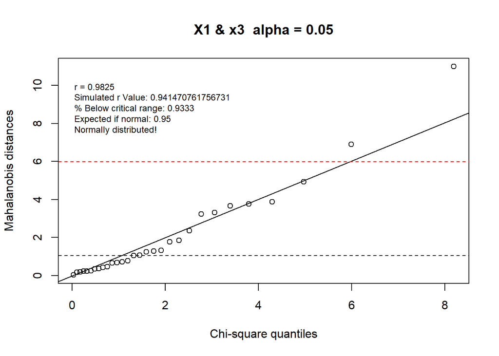

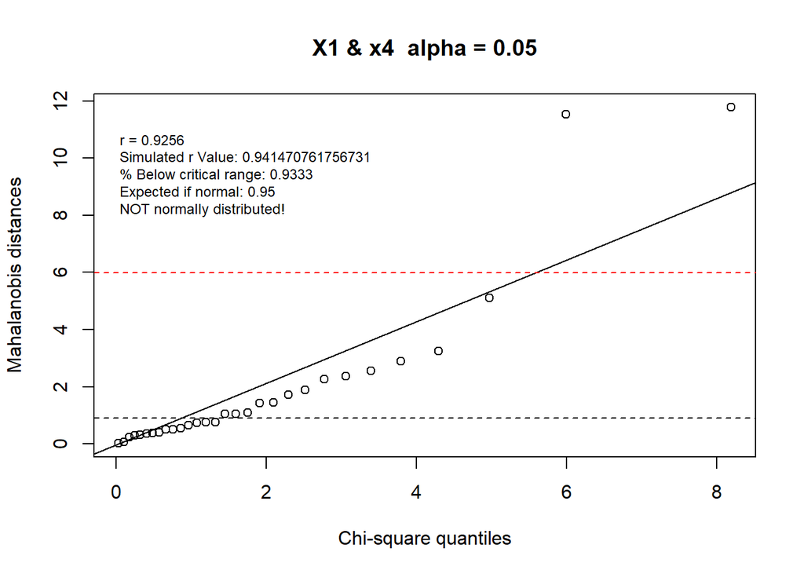

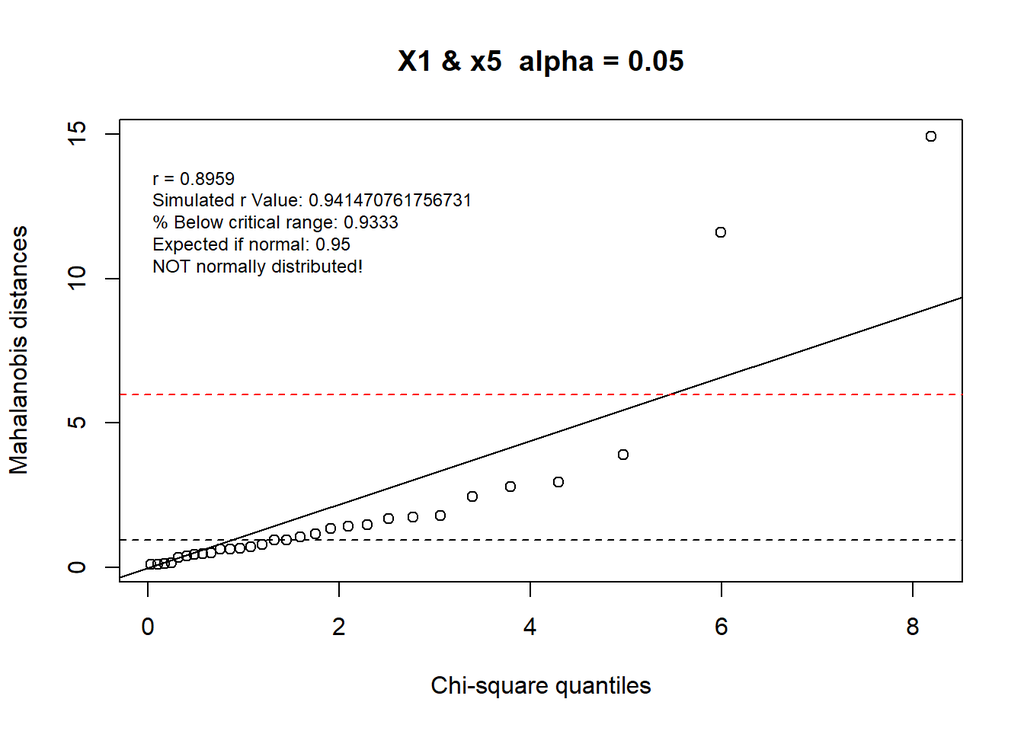

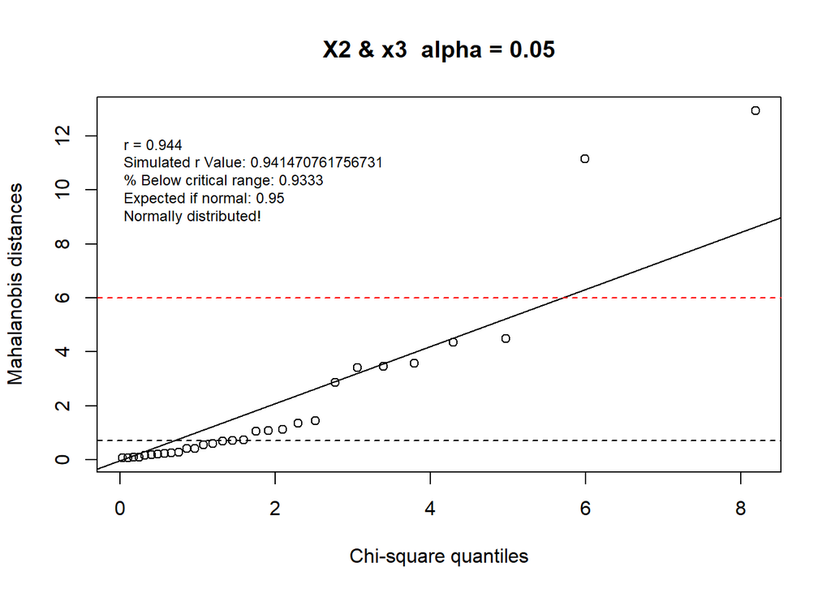

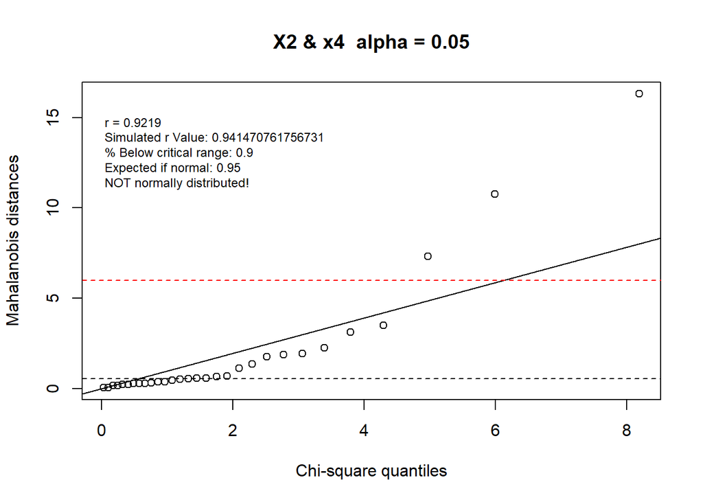

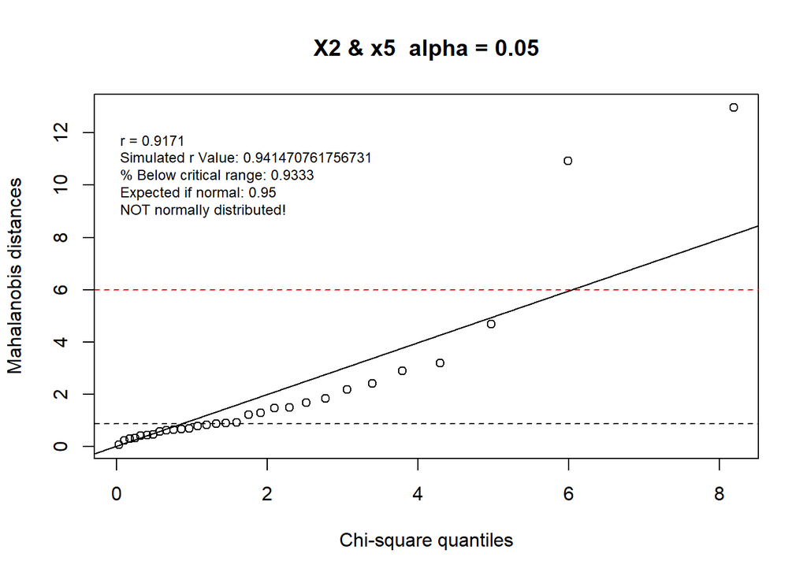

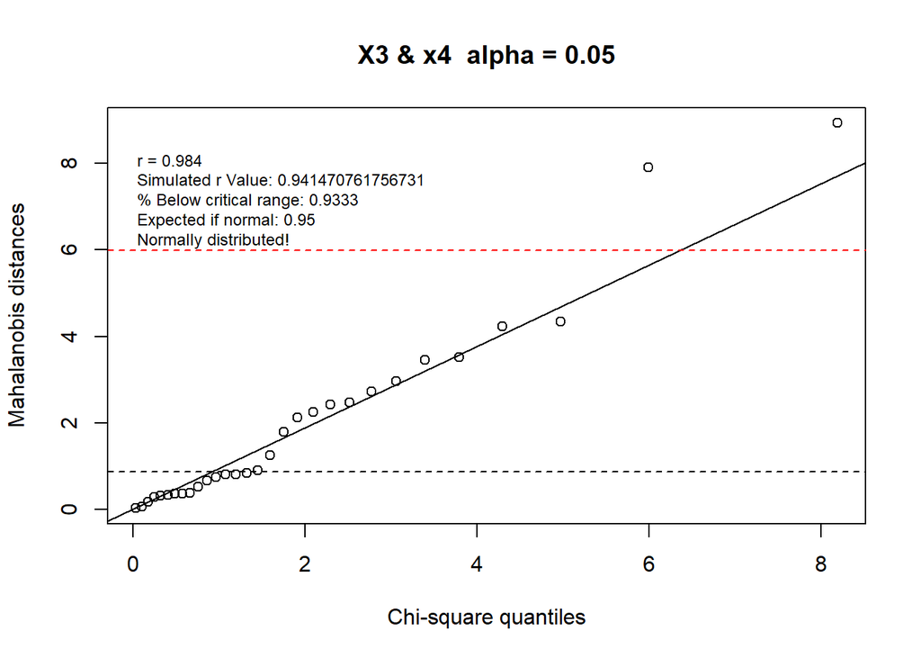

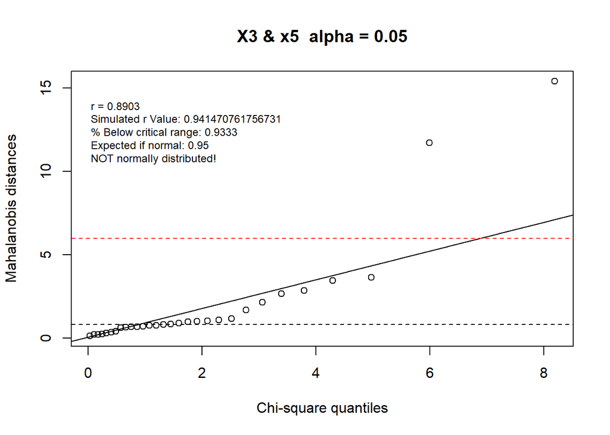

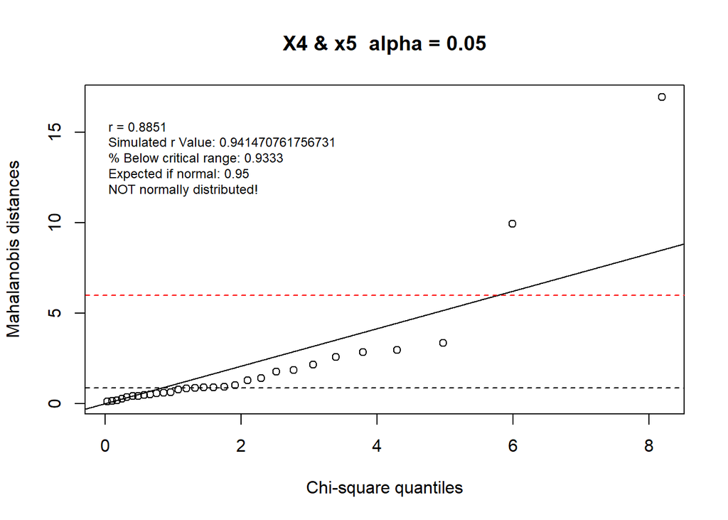

```r
bivar_pairs <- function(data_frame, significance = 0.05, remove_outliers = FALSE, n_outliers = 1, n_simulations = 10000) {

sim_cor <- FindcrikChi(n = length(data_frame[,1]),
                          p = 2,
                          alpha = significance,
                          n_simulations)

prev <- c()
i = 1
for (col_name in colnames(data_frame)){

  j = 1
  for (col_name_inner in colnames(data_frame)){

    if (i == j){
      j = j + 1
      next
    }

    else if (j %in% prev){
      j = j + 1
      next
    }

    else{
      multi_var_norm(df = data_frame[, c(i, j)],
                 sim_cor = sim_cor,
                 alpha = significance,
                 name = paste0("X", i, " & ", "x", j, " "),
                 remove_outlier = remove_outliers,
                 n_outliers = n_outliers)

    }
    j = j + 1
  }
  prev <- append(prev, i)
  i = i + 1
  }
}

bivar_pairs(df, significance = 0.05)
```

This gives the following result:  
- X1 and X2: Normal  
- x1 and x3: Normal  
- X1 and x4: Not normal  
- x1 and x5: Not normal - x2 and x3: Normal  
- x2 and x4: Not normal  
- x2 and x5: Not normal  
- x3 and x4: Normal distributed  
- x3 and x5: Not normal distributed  
- x4 and x5: Not normal distributed

Let us try, by removing outliers and see how this changes it:

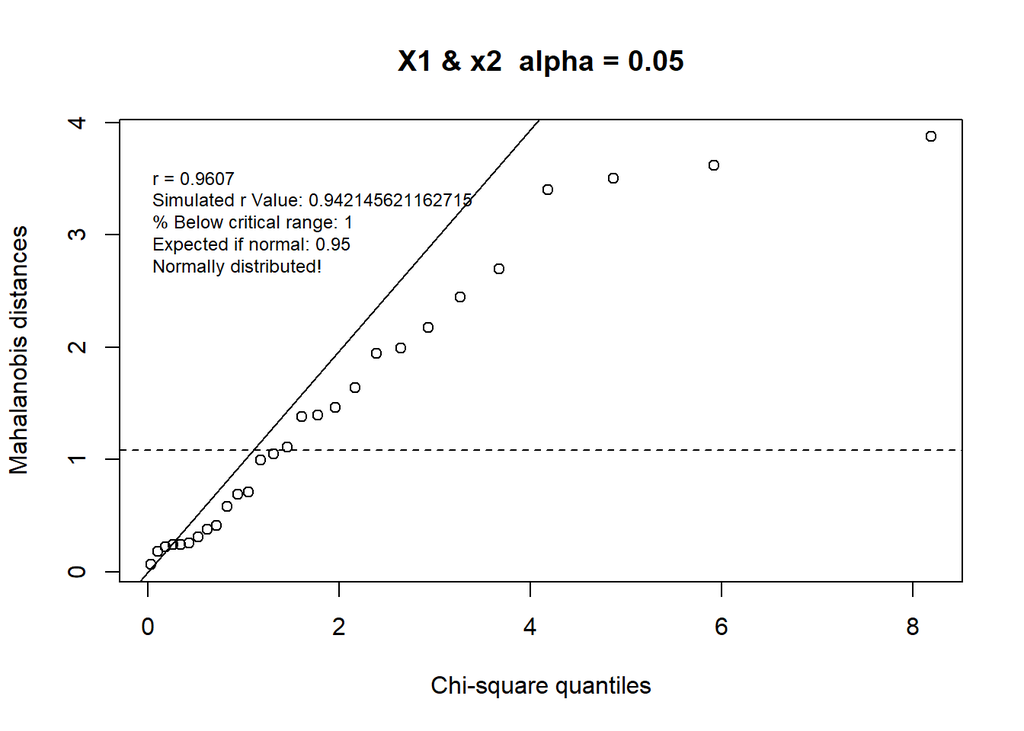

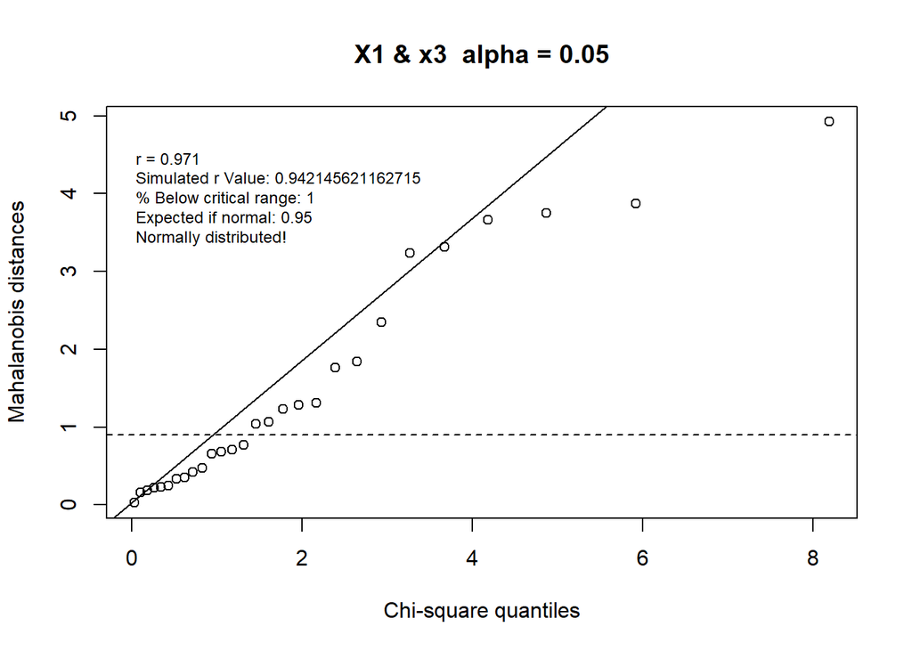

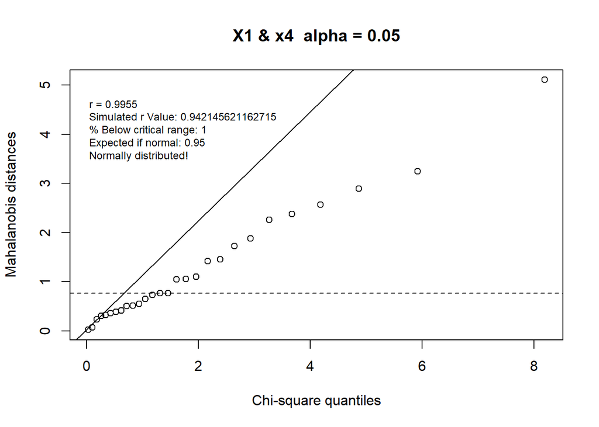

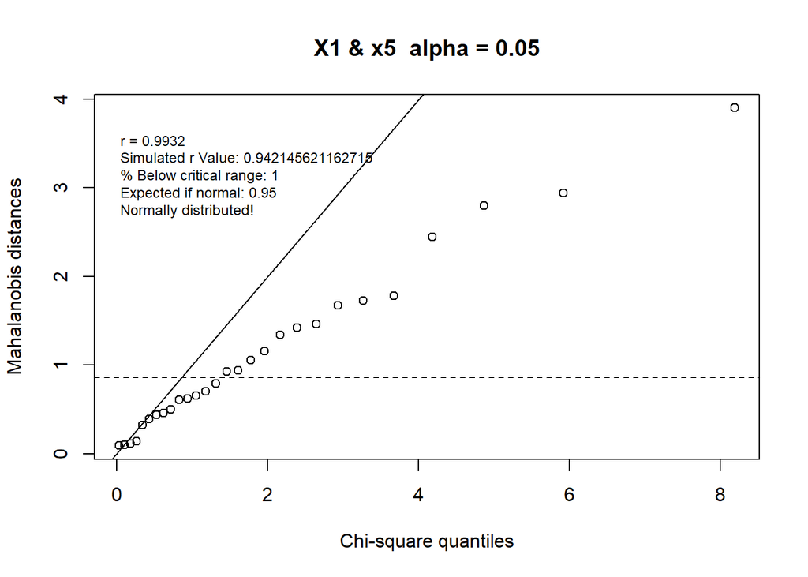

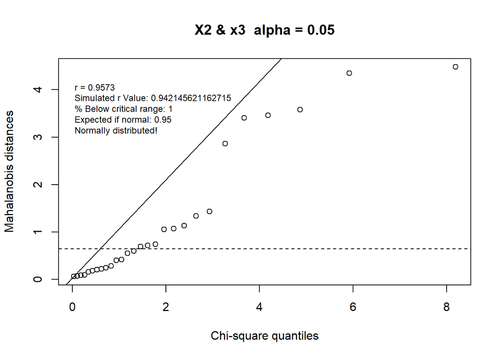

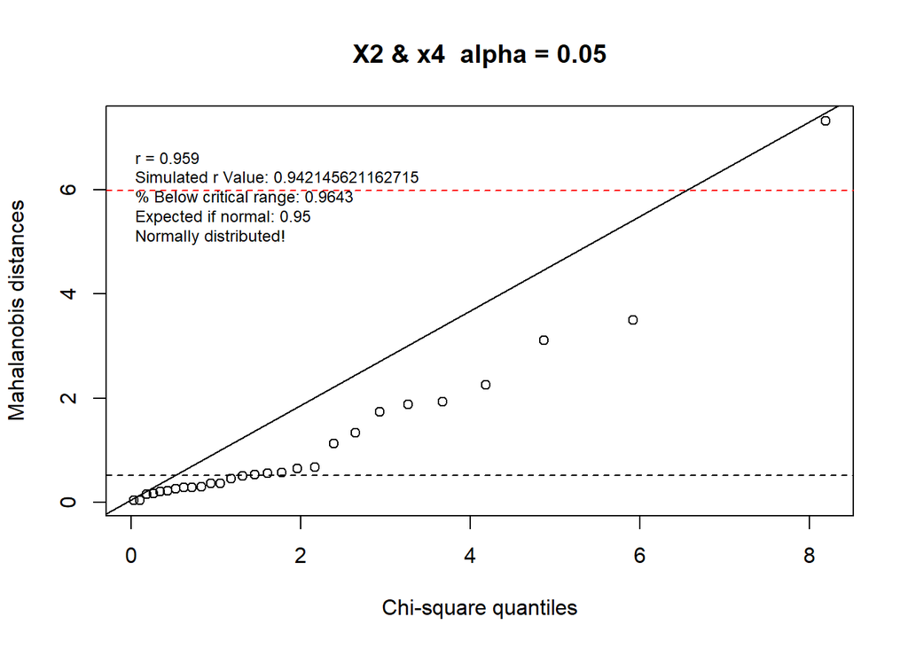

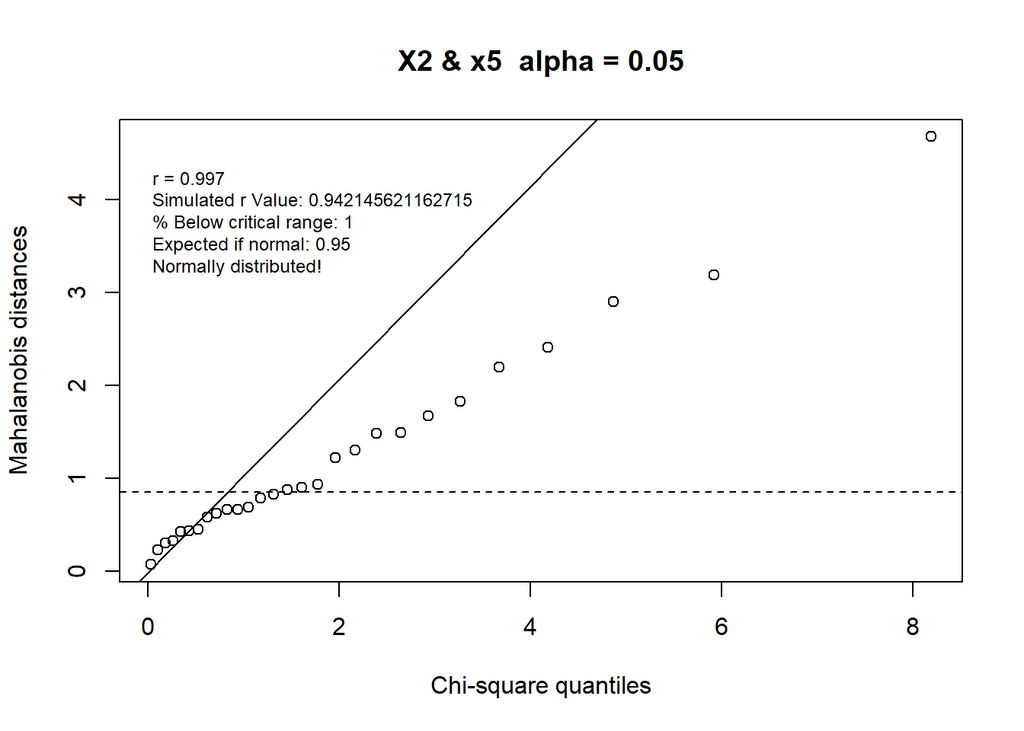

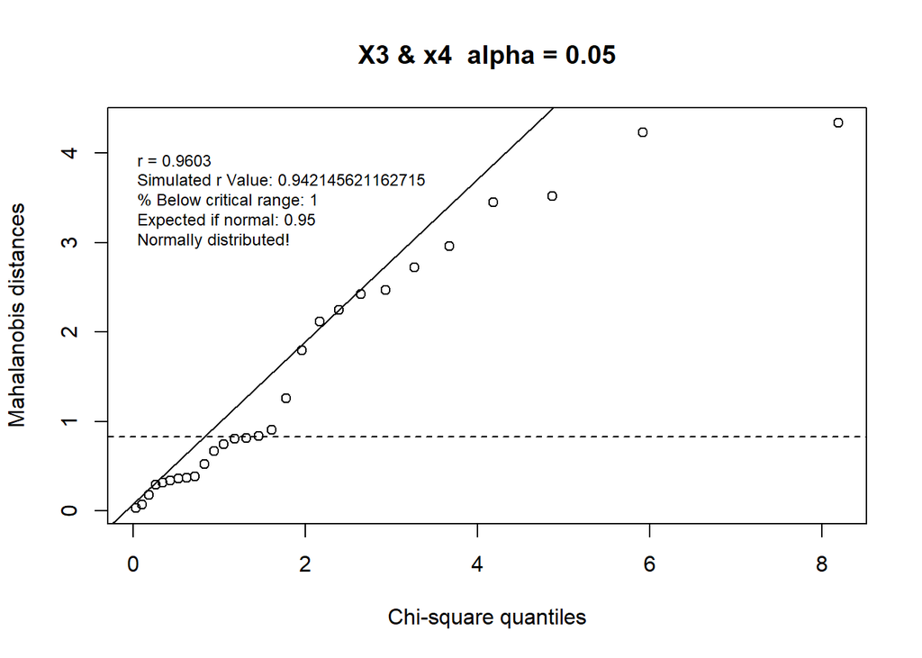

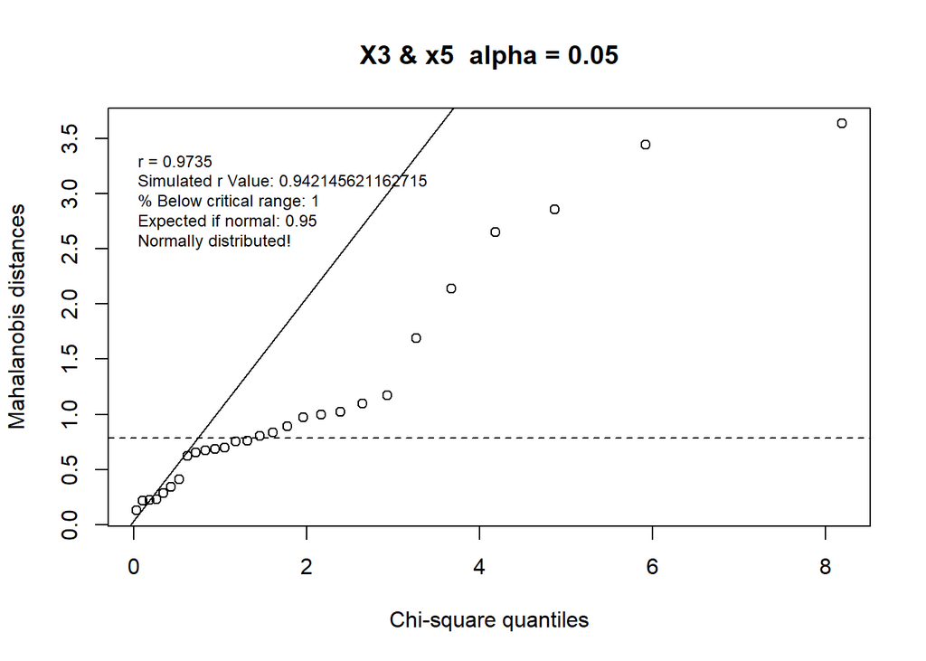

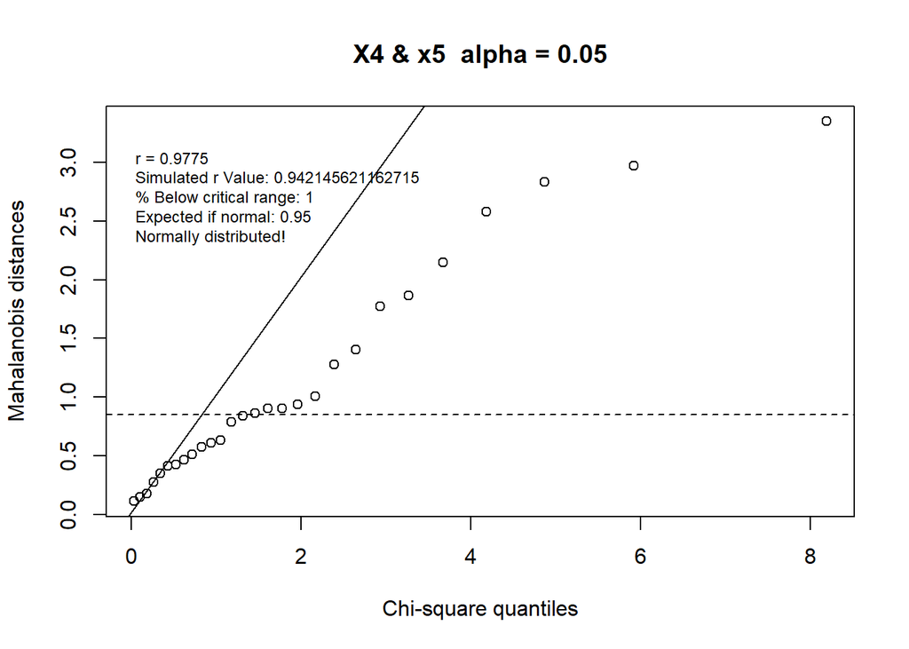

```r
bivar_pairs(df, significance = 0.05, remove_outliers = TRUE, n_outliers = 2)
```

Interestingtly all the data is normally distributed if we just remove the two outliers.  
Let us now try to do it with all attributes.

## Normality of all attributes

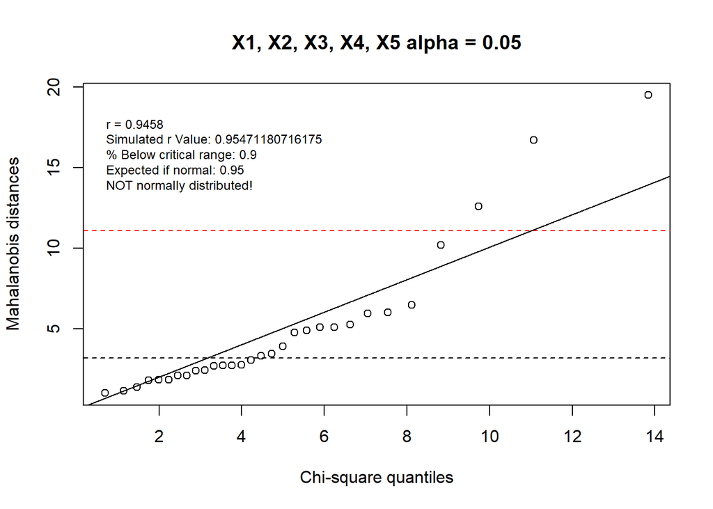

```r
sim_cor <- FindcrikChi(n = length(df[,1]),
                          p = ncol(df),
                          alpha = 0.05,
                          n_simulations = 10000)

multi_var_norm(df, sim_cor, 0.05, "X1, X2, X3, X4, X5")
```

The whole data set is not normally distributed, which fits the theorem that states, that if a subset is not normally distributed then the whole data set will not be normally distributed.

What if we remove two outliers again?

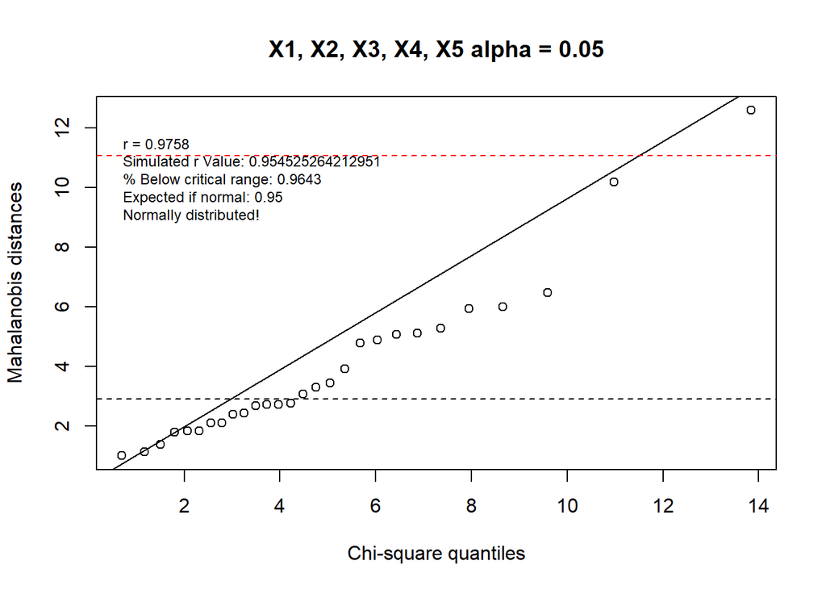

```r
sim_cor <- FindcrikChi(n = length(df[,1]),
                          p = ncol(df),
                          alpha = 0.05,
                          n_simulations = 10000)

multi_var_norm(df, sim_cor, 0.05, "X1, X2, X3, X4, X5", remove_outlier = TRUE, n_outliers = 2)
```

Then the data set is suddenly normally distributed. Let’s try and transform the dataset.